# Master_Юлия Шаталина_review (1)

## 3. Обучение модели

Зафиксируем Random State

```python
RS = 12345
```

Выберем сразу несколько алгоритмов для решения задачи классификации

```python
# Параметры базовых алгоритмов


gbc_params = {'learning_rate': np.arange(0.1, 0.6, 0.1)}    # Параметры для классификатора GradientBoostingClassifier

rfc_params = {'n_estimators': range(10, 100, 10),  # Параметры для классификатора RandomForestClassifier
              'min_samples_leaf': range(1, 7),
              'class_weight': ['balanced'],
              'max_depth': [None, 10, 20]}

svc_params = {'kernel': ['linear', 'rbf'],
'C': np.arange(0.1, 1, 0.2),
'class_weight': ['balanced']}                       # Параметры для классификатора SVC

lr_params = {'C': np.arange(0.2, 1, 0.1),
             'class_weight': ['balanced']}          # Параметры для классификатора LogisticRegression


cb_params = {'verbose': [False],                  # Параметры для классификатора CatBoostClassifier
             'iterations': [300],
             'learning_rate': [0.1, 0.3],
             'l2_leaf_reg': [3, 9]
              }
```

```python
# GridSearch для каждой из моделей

gbc = GradientBoostingClassifier(random_state=RS)  # Определение объекта классификатора GradientBoostingClassifier
rfc = RandomForestClassifier(random_state=RS)      # Определение объекта классификатора RandomForestClassifier
svc = SVC(random_state=RS, probability=True)       # Определение объекта классификатора SVC
lr = LogisticRegression(random_state=RS,
                        solver = 'liblinear')      # Определение объекта классификатора LogisticRegression
cb = CatBoostClassifier(random_state=RS, cat_features=features_cat)           # Определение объекта классификатора CatBoostClassifier
dm = DummyClassifier(strategy="most_frequent", random_state=RS)        # Определение объекта классификатора DummyClassifier

gscv_gbc = GridSearchCV(estimator=gbc, param_grid=gbc_params, scoring='roc_auc', cv=3)  # Определение объекта кросс-валидации для GradientBoostingClassifier
gscv_rfc = GridSearchCV(estimator=rfc, param_grid=rfc_params, scoring='roc_auc', cv=3)  # Определение объекта кросс-валидации для RandomForestClassifier
gscv_svc = GridSearchCV(estimator=svc, param_grid=svc_params, scoring='roc_auc',  cv=3)  # Определение объекта кросс-валидации для SVC
gscv_lr = GridSearchCV(estimator=lr, param_grid=lr_params, scoring='roc_auc', cv=3)     # Определение объекта кросс-валидации для LogisticRegression
gscv_cb = GridSearchCV(estimator=cb, param_grid=cb_params, scoring='roc_auc',  cv=3)     # Определение объекта кросс-валидации для CatBoost

gbc_model = gscv_gbc.fit(features_train_new, target_train)  # Обучение модели GradientBoostingClassifier на кросс-валидации
rfc_model = gscv_rfc.fit(features_train_new, target_train)  # Обучение модели RandomForestClassifier на кросс-валидации
svc_model = gscv_svc.fit(features_train_new, target_train)  # Обучение модели SVC на кросс-валидации
lr_model = gscv_lr.fit(features_train_new, target_train)    # Обучение модели LogisticRegression на кросс-валидации
cb_model = gscv_cb.fit(features_train, target_train)    # Обучение модели CatBoost на кросс-валидации на сырых данных
dm_model = dm.fit(features_train_new, target_train)
```

```python
# Получение лучших параметров для классификаторов полученных на кросс-валидации
print('Лучшие параметры:')
print(f'GradientBoostingClassifier %s \nRandomForestClassifier %s \nSVC %s \nLogisticRegression %s \nCatBoostClassifier %s' %(
                                                                gscv_gbc.best_params_,
                                                                gscv_rfc.best_params_,
                                                                gscv_svc.best_params_,
                                                                gscv_lr.best_params_,
                                                                gscv_cb.best_params_))
```

```
Лучшие параметры:
GradientBoostingClassifier {'learning_rate': 0.1}
RandomForestClassifier {'class_weight': 'balanced', 'max_depth': 10, 'min_samples_leaf': 5, 'n_estimators': 70}
SVC {'C': 0.1, 'class_weight': 'balanced', 'kernel': 'linear'}
LogisticRegression {'C': 0.30000000000000004, 'class_weight': 'balanced'}
CatBoostClassifier {'iterations': 300, 'l2_leaf_reg': 9, 'learning_rate': 0.1, 'verbose': False}
```

```python
gbc_predict = gbc_model.predict(features_test_new)
rfc_predict = rfc_model.predict(features_test_new)
svc_predict = svc_model.predict(features_test_new)
lr_predict = lr_model.predict(features_test_new)
cb_predict = cb_model.predict(features_test)
dm_predict = dm_model.predict(features_test_new)
```

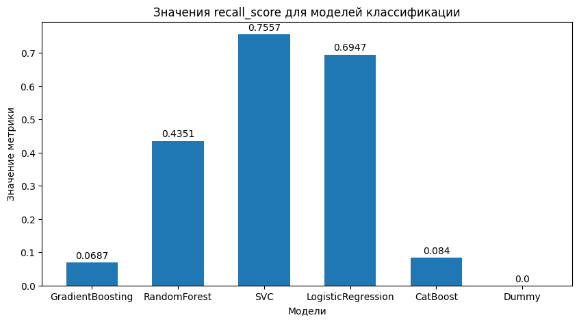

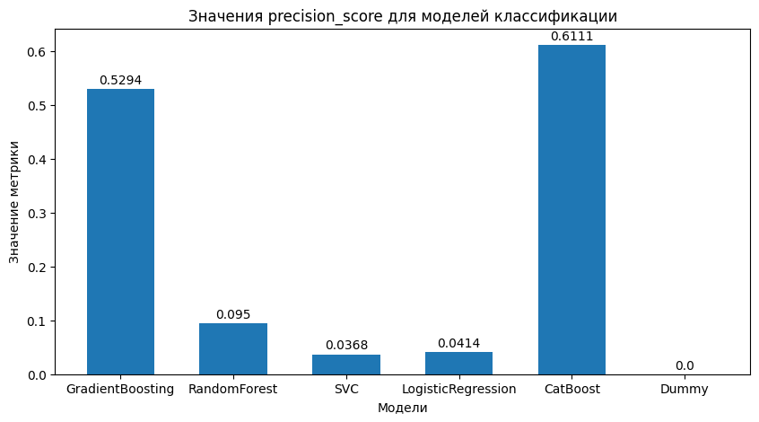

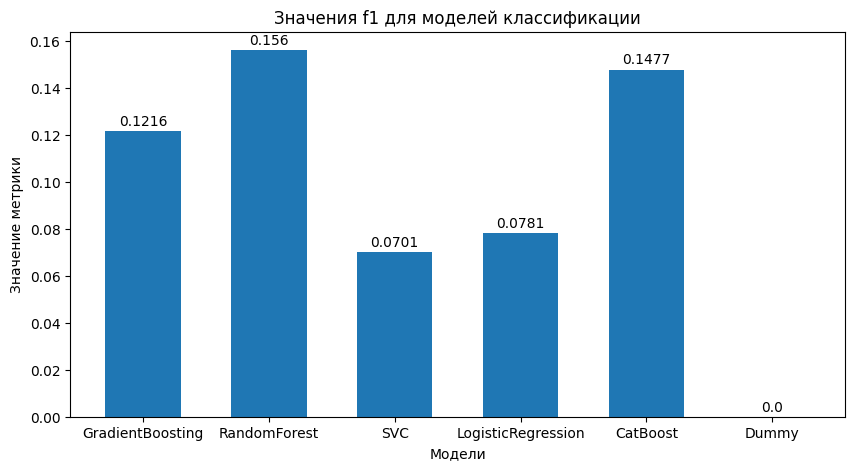

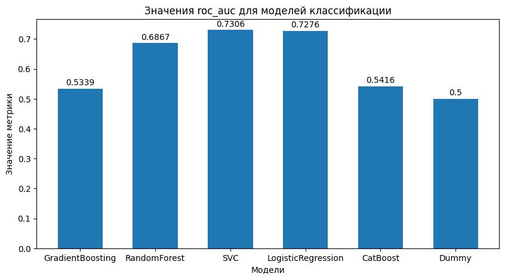

```python
# Получение значений полноты моделей классификаторов
metrics_scores = [recall_score, precision_score, f1_score, roc_auc_score]
predicts = [gbc_predict, rfc_predict, svc_predict, lr_predict, cb_predict, dm_predict]
models_names = ['GradientBoosting', 'RandomForest', 'SVC', 'LogisticRegression', 'CatBoost', 'Dummy']
scores_names = ['recall_score', 'precision_score', 'f1', 'roc_auc']
values_list = []
values_list_tab = []

for i, score in enumerate(metrics_scores):
    for predict in predicts:
        values_list.append(round(score(target_test, predict),4))

    x = np.arange(len(models_names))  # Список координат столбцов по x

    fig, ax = plt.subplots(figsize=(10,5))  # Определение фигуры и осей
    rects = ax.bar(x, values_list, 0.6)  # Определение колонок для данных

    # Указание подписей для осей, таблицы, легенды
    ax.set_ylabel('Значение метрики')
    ax.set_xlabel('Модели')
    ax.set_title(f'Значения {scores_names[i]} для моделей классификации')
    ax.set_xticks(x)
    ax.set_xticklabels(models_names)

    # Определение функции для отображения столбцов с аннотациями
    def autolabel(rects):
        for rect in rects:
            height = rect.get_height()
            # Задание параметров для аннотаций
            ax.annotate('{}'.format(height),
                        xy=(rect.get_x() + rect.get_width() / 2, height), # Получение точек координат для текста
                        xytext=(0, 2),    # Высота текста над столбцами
                        # Расположение текста относительно столбцов
                        textcoords="offset points",
                        ha='center', va='bottom')

    autolabel(rects)  # Выполнение функции
    values_list_tab.append(values_list)
    values_list = []

plt.show()
```

```python
values_list_df = pd.DataFrame(values_list_tab)
```

```python
values_list_df.columns = models_names
values_list_df.index = scores_names
values_list_df
```

|  | GradientBoosting | RandomForest | SVC | LogisticRegression | CatBoost | Dummy |
| --- | --- | --- | --- | --- | --- | --- |
| recall_score | 0.0687 | 0.4351 | 0.7557 | 0.6947 | 0.0840 | 0.0 |
| precision_score | 0.5294 | 0.0950 | 0.0368 | 0.0414 | 0.6111 | 0.0 |
| f1 | 0.1216 | 0.1560 | 0.0701 | 0.0781 | 0.1477 | 0.0 |
| roc_auc | 0.5339 | 0.6867 | 0.7306 | 0.7276 | 0.5416 | 0.5 |

Показатели лучшей метрики получились у модели SVC с параметрами {'C': 0.1, 'class_weight': 'balanced', 'kernel': 'linear'} Построим матрицу ошибок для нее и график ROC-AUC.

```python
pred= gscv_svc.best_estimator_.predict(features_test_new)
```

```python
confusion_matrix = metrics.confusion_matrix(target_test, pred)
```

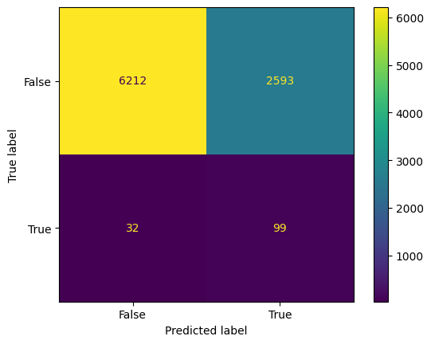

```python
cm_display = metrics.ConfusionMatrixDisplay(confusion_matrix = confusion_matrix, display_labels = [False, True])

cm_display.plot()
plt.show()
```

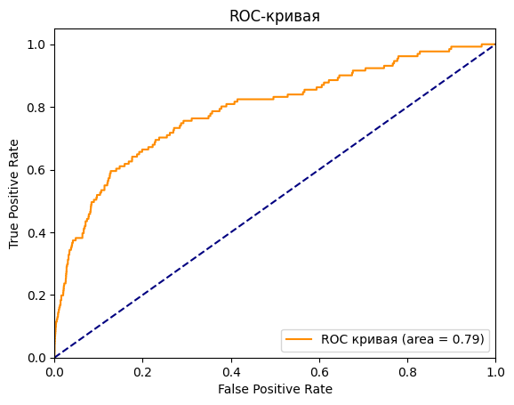

```
ROC_AUC Метрика:  0.79
```

```python
fpr, tpr, treshold = roc_curve(target_test, gscv_svc.best_estimator_.predict_proba(features_test_new)[:, 1])
roc_auc = auc(fpr, tpr)
# строим график
plt.plot(fpr, tpr, color='darkorange',
         label='ROC кривая (area = %0.2f)' % roc_auc)
plt.plot([0, 1], [0, 1], color='navy', linestyle='--')
plt.xlim([0.0, 1.0])
plt.ylim([0.0, 1.05])
plt.xlabel('False Positive Rate')
plt.ylabel('True Positive Rate')
plt.title('ROC-кривая')
plt.legend(loc="lower right")
plt.show()
print('ROC_AUC Метрика: ', round(roc_auc_score(target_test, gscv_svc.best_estimator_.predict_proba(features_test_new)[:, 1]), 2))
```

### 3.1. Добавление признаков временного ряда

Переформатируем первоначальный датасет.

```python
df
```

|  | client_id | quantity | price | date | market |
| --- | --- | --- | --- | --- | --- |
| 0 | 1515915625468068833 | 1 | 3499.0 | 2023-09-08 00:00:00 | 0 |
| 1 | 1515915625468068833 | 1 | 3499.0 | 2023-09-08 00:00:00 | 0 |
| 2 | 1515915625468068833 | 1 | 3499.0 | 2023-09-08 00:00:00 | 0 |
| 3 | 1515915625468068833 | 1 | 2450.0 | 2023-09-08 00:00:00 | 0 |
| 4 | 1515915625468068833 | 1 | 2450.0 | 2023-09-08 00:00:00 | 0 |
| ... | ... | ... | ... | ... | ... |
| 48177 | 1515915625575803144 | 1 | 29998.0 | 2023-04-29 11:19:29 | 2 |
| 48178 | 1515915625575803144 | 1 | 29998.0 | 2023-04-29 11:19:29 | 2 |
| 48179 | 1515915625575808251 | 1 | 25998.0 | 2023-04-29 11:46:30 | 2 |
| 48180 | 1515915625575809442 | 1 | 15998.0 | 2023-04-29 08:48:11 | 2 |
| 48181 | 1515915625575809442 | 1 | 15998.0 | 2023-04-29 08:52:13 | 2 |

182097 rows × 5 columns

Группируем данные по клиентам и дате, количество заказов и сумму покупок - суммируем

```python
df_sort = df.groupby(['client_id', 'date']).agg({'quantity':'sum', 'price': 'sum'}).reset_index()
df_sort
```

|  | client_id | date | quantity | price |
| --- | --- | --- | --- | --- |
| 0 | 1515915625440099873 | 2023-07-16 08:25:31 | 1 | 31998.0 |
| 1 | 1515915625440099873 | 2023-08-09 08:59:08 | 1 | 1218.0 |
| 2 | 1515915625440939402 | 2023-01-30 13:13:37 | 1 | 75998.0 |
| 3 | 1515915625440944408 | 2023-03-01 10:21:12 | 1 | 882.0 |
| 4 | 1515915625440944408 | 2023-05-02 08:49:57 | 1 | 6298.0 |
| ... | ... | ... | ... | ... |
| 65571 | 1515915626005014483 | 2023-09-13 00:00:00 | 1 | 7534.0 |
| 65572 | 1515915626010039507 | 2023-10-02 00:00:00 | 2 | 26039.0 |
| 65573 | 1515915626011484905 | 2023-10-13 00:00:00 | 5 | 32913.0 |
| 65574 | 1515915626012131867 | 2023-09-12 00:00:00 | 1 | 25834.0 |
| 65575 | 1515915626013602677 | 2023-10-11 00:00:00 | 3 | 111535.0 |

65576 rows × 4 columns

```python
df_sort  = df_sort.sort_values(['client_id','date'])
```

Создадим временные признаки RFM нарастающим итогом.

```python
df_sort['monetary'] = df_sort.groupby('client_id')['price'].cumsum()
df_sort['recency'] = df_sort.groupby('client_id')['date'].diff().dt.days.fillna(999).astype(int)
df_sort['frequency'] = df_sort.groupby('client_id')['date'].cumcount()+1
```

```python
df_sort
```

|  | client_id | date | quantity | price | monetary | recency | frequency |
| --- | --- | --- | --- | --- | --- | --- | --- |
| 0 | 1515915625440099873 | 2023-07-16 08:25:31 | 1 | 31998.0 | 31998.0 | 999 | 1 |
| 1 | 1515915625440099873 | 2023-08-09 08:59:08 | 1 | 1218.0 | 33216.0 | 24 | 2 |
| 2 | 1515915625440939402 | 2023-01-30 13:13:37 | 1 | 75998.0 | 75998.0 | 999 | 1 |
| 3 | 1515915625440944408 | 2023-03-01 10:21:12 | 1 | 882.0 | 882.0 | 999 | 1 |
| 4 | 1515915625440944408 | 2023-05-02 08:49:57 | 1 | 6298.0 | 7180.0 | 61 | 2 |
| ... | ... | ... | ... | ... | ... | ... | ... |
| 65571 | 1515915626005014483 | 2023-09-13 00:00:00 | 1 | 7534.0 | 7534.0 | 999 | 1 |
| 65572 | 1515915626010039507 | 2023-10-02 00:00:00 | 2 | 26039.0 | 26039.0 | 999 | 1 |
| 65573 | 1515915626011484905 | 2023-10-13 00:00:00 | 5 | 32913.0 | 32913.0 | 999 | 1 |
| 65574 | 1515915626012131867 | 2023-09-12 00:00:00 | 1 | 25834.0 | 25834.0 | 999 | 1 |
| 65575 | 1515915626013602677 | 2023-10-11 00:00:00 | 3 | 111535.0 | 111535.0 | 999 | 1 |

65576 rows × 7 columns

Отсортируем данные по дате, сгруппируем по клиентам и дате. Сделаем признак - количество дней до следующей покупки сдвигом. Все пропущенные значения заполним данным "-999", поставим вначале знак "-", чтобы разница была в днях положительной.

```python
df_sort = df_sort.sort_values('date', ascending= False )
```

```python
df_sort['days_to_next_purchase'] = -df_sort.groupby('client_id')['date'].diff().dt.days.fillna(-999).astype(int)
df_sort
```

|  | client_id | date | quantity | price | monetary | recency | frequency | days_to_next_purchase |
| --- | --- | --- | --- | --- | --- | --- | --- | --- |
| 22227 | 1515915625517812413 | 2023-10-26 13:34:11 | 1 | 119998.0 | 119998.0 | 999 | 1 | 999 |
| 51554 | 1515915625581725735 | 2023-10-26 13:15:32 | 1 | 77978.0 | 77978.0 | 999 | 1 | 999 |
| 53942 | 1515915625588069308 | 2023-10-26 12:43:55 | 2 | 11760.0 | 11760.0 | 999 | 1 | 999 |
| 53671 | 1515915625587268787 | 2023-10-26 11:23:08 | 1 | 298.0 | 298.0 | 999 | 1 | 999 |
| 35036 | 1515915625547041467 | 2023-10-26 11:07:15 | 1 | 16998.0 | 16998.0 | 999 | 1 | 999 |
| ... | ... | ... | ... | ... | ... | ... | ... | ... |
| 61760 | 1515915625857065470 | 2022-10-26 00:00:00 | 5 | 174768.0 | 174768.0 | 999 | 1 | 999 |
| 15472 | 1515915625500418210 | 2022-10-26 00:00:00 | 1 | 1859.0 | 1859.0 | 999 | 1 | 999 |
| 40841 | 1515915625558655965 | 2022-10-26 00:00:00 | 3 | 3298.0 | 3298.0 | 999 | 1 | 999 |
| 51578 | 1515915625581772632 | 2022-10-26 00:00:00 | 1 | 2100.0 | 2100.0 | 999 | 1 | 999 |
| 54008 | 1515915625588327029 | 2022-10-26 00:00:00 | 1 | 2499.0 | 2499.0 | 999 | 1 | 999 |

65576 rows × 8 columns

```python
df_sort['days_to_next_purchase'].value_counts()
```

```
days_to_next_purchase
999    47004
1       9966
2        597
3        274
4        255
       ...
295        1
268        1
242        1
246        1
316        1
Name: count, Length: 326, dtype: int64
```

Сформируем целевой признак - в него попадут все клиенты, которые совершат покупки в период менее 30 дней.

```python
df_sort['target'] = (df_sort['days_to_next_purchase'] <= 30).astype(int)
df_sort
```

|  | client_id | date | quantity | price | monetary | recency | frequency | days_to_next_purchase | target |
| --- | --- | --- | --- | --- | --- | --- | --- | --- | --- |
| 22227 | 1515915625517812413 | 2023-10-26 13:34:11 | 1 | 119998.0 | 119998.0 | 999 | 1 | 999 | 0 |
| 51554 | 1515915625581725735 | 2023-10-26 13:15:32 | 1 | 77978.0 | 77978.0 | 999 | 1 | 999 | 0 |
| 53942 | 1515915625588069308 | 2023-10-26 12:43:55 | 2 | 11760.0 | 11760.0 | 999 | 1 | 999 | 0 |
| 53671 | 1515915625587268787 | 2023-10-26 11:23:08 | 1 | 298.0 | 298.0 | 999 | 1 | 999 | 0 |
| 35036 | 1515915625547041467 | 2023-10-26 11:07:15 | 1 | 16998.0 | 16998.0 | 999 | 1 | 999 | 0 |
| ... | ... | ... | ... | ... | ... | ... | ... | ... | ... |
| 61760 | 1515915625857065470 | 2022-10-26 00:00:00 | 5 | 174768.0 | 174768.0 | 999 | 1 | 999 | 0 |
| 15472 | 1515915625500418210 | 2022-10-26 00:00:00 | 1 | 1859.0 | 1859.0 | 999 | 1 | 999 | 0 |
| 40841 | 1515915625558655965 | 2022-10-26 00:00:00 | 3 | 3298.0 | 3298.0 | 999 | 1 | 999 | 0 |
| 51578 | 1515915625581772632 | 2022-10-26 00:00:00 | 1 | 2100.0 | 2100.0 | 999 | 1 | 999 | 0 |
| 54008 | 1515915625588327029 | 2022-10-26 00:00:00 | 1 | 2499.0 | 2499.0 | 999 | 1 | 999 | 0 |

65576 rows × 9 columns

Проверим соотношение 0 и 1 в целевом признаке.

```python
df_sort['target'].value_counts()
```

```
target
0    51560
1    14016
Name: count, dtype: int64
```

```python
df_sort = df_sort.sort_values(['date'])
df_sort
```

|  | client_id | date | quantity | price | monetary | recency | frequency | days_to_next_purchase | target |
| --- | --- | --- | --- | --- | --- | --- | --- | --- | --- |
| 54008 | 1515915625588327029 | 2022-10-26 00:00:00 | 1 | 2499.0 | 2499.0 | 999 | 1 | 999 | 0 |
| 10138 | 1515915625489888679 | 2022-10-26 00:00:00 | 3 | 2213.0 | 2213.0 | 999 | 1 | 999 | 0 |
| 3083 | 1515915625468222486 | 2022-10-26 00:00:00 | 2 | 7998.0 | 7998.0 | 999 | 1 | 999 | 0 |
| 53849 | 1515915625587818098 | 2022-10-26 00:00:00 | 2 | 17998.0 | 17998.0 | 999 | 1 | 999 | 0 |
| 51578 | 1515915625581772632 | 2022-10-26 00:00:00 | 1 | 2100.0 | 2100.0 | 999 | 1 | 999 | 0 |
| ... | ... | ... | ... | ... | ... | ... | ... | ... | ... |
| 35036 | 1515915625547041467 | 2023-10-26 11:07:15 | 1 | 16998.0 | 16998.0 | 999 | 1 | 999 | 0 |
| 53671 | 1515915625587268787 | 2023-10-26 11:23:08 | 1 | 298.0 | 298.0 | 999 | 1 | 999 | 0 |
| 53942 | 1515915625588069308 | 2023-10-26 12:43:55 | 2 | 11760.0 | 11760.0 | 999 | 1 | 999 | 0 |
| 51554 | 1515915625581725735 | 2023-10-26 13:15:32 | 1 | 77978.0 | 77978.0 | 999 | 1 | 999 | 0 |
| 22227 | 1515915625517812413 | 2023-10-26 13:34:11 | 1 | 119998.0 | 119998.0 | 999 | 1 | 999 | 0 |

65576 rows × 9 columns

Отчечем данные за последние 30 дней с конца данных.

```python
df_sort_history = df_sort[df_sort['date'] < date_last]
df_sort_history
```

|  | client_id | date | quantity | price | monetary | recency | frequency | days_to_next_purchase | target |
| --- | --- | --- | --- | --- | --- | --- | --- | --- | --- |
| 54008 | 1515915625588327029 | 2022-10-26 00:00:00 | 1 | 2499.0 | 2499.0 | 999 | 1 | 999 | 0 |
| 10138 | 1515915625489888679 | 2022-10-26 00:00:00 | 3 | 2213.0 | 2213.0 | 999 | 1 | 999 | 0 |
| 3083 | 1515915625468222486 | 2022-10-26 00:00:00 | 2 | 7998.0 | 7998.0 | 999 | 1 | 999 | 0 |
| 53849 | 1515915625587818098 | 2022-10-26 00:00:00 | 2 | 17998.0 | 17998.0 | 999 | 1 | 999 | 0 |
| 51578 | 1515915625581772632 | 2022-10-26 00:00:00 | 1 | 2100.0 | 2100.0 | 999 | 1 | 999 | 0 |
| ... | ... | ... | ... | ... | ... | ... | ... | ... | ... |
| 28239 | 1515915625525609711 | 2023-09-26 13:17:05 | 1 | 1998.0 | 1998.0 | 999 | 1 | 999 | 0 |
| 5278 | 1515915625480099574 | 2023-09-26 13:17:05 | 2 | 22.0 | 22.0 | 999 | 1 | 999 | 0 |
| 52703 | 1515915625584893248 | 2023-09-26 13:18:48 | 1 | 83998.0 | 83998.0 | 999 | 1 | 999 | 0 |
| 20089 | 1515915625516600947 | 2023-09-26 13:26:23 | 1 | 2078.0 | 2078.0 | 999 | 1 | 1 | 1 |
| 20090 | 1515915625516600947 | 2023-09-26 13:29:02 | 1 | 165.0 | 2243.0 | 0 | 2 | 999 | 0 |

61487 rows × 9 columns

введем признаки временного ряда - день месяца покупки, день недели, месяц, неделя года.

```python
df_sort_history['day_of_month'] = df_sort_history['date'].dt.day
df_sort_history['day_of_week'] = df_sort_history['date'].dt.dayofweek
df_sort_history['month'] = df_sort_history['date'].dt.month
df_sort_history['week_of_year'] = df_sort_history['date'].dt.isocalendar().week
```

```python
df_sort_history
```

|  | client_id | date | quantity | price | monetary | recency | frequency | days_to_next_purchase | target | day_of_month | day_of_week | month | week_of_year |
| --- | --- | --- | --- | --- | --- | --- | --- | --- | --- | --- | --- | --- | --- |
| 54008 | 1515915625588327029 | 2022-10-26 00:00:00 | 1 | 2499.0 | 2499.0 | 999 | 1 | 999 | 0 | 26 | 2 | 10 | 43 |
| 10138 | 1515915625489888679 | 2022-10-26 00:00:00 | 3 | 2213.0 | 2213.0 | 999 | 1 | 999 | 0 | 26 | 2 | 10 | 43 |
| 3083 | 1515915625468222486 | 2022-10-26 00:00:00 | 2 | 7998.0 | 7998.0 | 999 | 1 | 999 | 0 | 26 | 2 | 10 | 43 |
| 53849 | 1515915625587818098 | 2022-10-26 00:00:00 | 2 | 17998.0 | 17998.0 | 999 | 1 | 999 | 0 | 26 | 2 | 10 | 43 |
| 51578 | 1515915625581772632 | 2022-10-26 00:00:00 | 1 | 2100.0 | 2100.0 | 999 | 1 | 999 | 0 | 26 | 2 | 10 | 43 |
| ... | ... | ... | ... | ... | ... | ... | ... | ... | ... | ... | ... | ... | ... |
| 28239 | 1515915625525609711 | 2023-09-26 13:17:05 | 1 | 1998.0 | 1998.0 | 999 | 1 | 999 | 0 | 26 | 1 | 9 | 39 |
| 5278 | 1515915625480099574 | 2023-09-26 13:17:05 | 2 | 22.0 | 22.0 | 999 | 1 | 999 | 0 | 26 | 1 | 9 | 39 |
| 52703 | 1515915625584893248 | 2023-09-26 13:18:48 | 1 | 83998.0 | 83998.0 | 999 | 1 | 999 | 0 | 26 | 1 | 9 | 39 |
| 20089 | 1515915625516600947 | 2023-09-26 13:26:23 | 1 | 2078.0 | 2078.0 | 999 | 1 | 1 | 1 | 26 | 1 | 9 | 39 |
| 20090 | 1515915625516600947 | 2023-09-26 13:29:02 | 1 | 165.0 | 2243.0 | 0 | 2 | 999 | 0 | 26 | 1 | 9 | 39 |

61487 rows × 13 columns

Сделаем индексами даты.

```python
df_sort_history = df_sort_history.set_index('date')
df_sort_history
```

| date | client_id | quantity | price | monetary | recency | frequency | days_to_next_purchase | target | day_of_month | day_of_week | month | week_of_year |
| --- | --- | --- | --- | --- | --- | --- | --- | --- | --- | --- | --- | --- |
| 2022-10-26 00:00:00 | 1515915625588327029 | 1 | 2499.0 | 2499.0 | 999 | 1 | 999 | 0 | 26 | 2 | 10 | 43 |
| 2022-10-26 00:00:00 | 1515915625489888679 | 3 | 2213.0 | 2213.0 | 999 | 1 | 999 | 0 | 26 | 2 | 10 | 43 |
| 2022-10-26 00:00:00 | 1515915625468222486 | 2 | 7998.0 | 7998.0 | 999 | 1 | 999 | 0 | 26 | 2 | 10 | 43 |
| 2022-10-26 00:00:00 | 1515915625587818098 | 2 | 17998.0 | 17998.0 | 999 | 1 | 999 | 0 | 26 | 2 | 10 | 43 |
| 2022-10-26 00:00:00 | 1515915625581772632 | 1 | 2100.0 | 2100.0 | 999 | 1 | 999 | 0 | 26 | 2 | 10 | 43 |
| ... | ... | ... | ... | ... | ... | ... | ... | ... | ... | ... | ... | ... |
| 2023-09-26 13:17:05 | 1515915625525609711 | 1 | 1998.0 | 1998.0 | 999 | 1 | 999 | 0 | 26 | 1 | 9 | 39 |
| 2023-09-26 13:17:05 | 1515915625480099574 | 2 | 22.0 | 22.0 | 999 | 1 | 999 | 0 | 26 | 1 | 9 | 39 |
| 2023-09-26 13:18:48 | 1515915625584893248 | 1 | 83998.0 | 83998.0 | 999 | 1 | 999 | 0 | 26 | 1 | 9 | 39 |
| 2023-09-26 13:26:23 | 1515915625516600947 | 1 | 2078.0 | 2078.0 | 999 | 1 | 1 | 1 | 26 | 1 | 9 | 39 |
| 2023-09-26 13:29:02 | 1515915625516600947 | 1 | 165.0 | 2243.0 | 0 | 2 | 999 | 0 | 26 | 1 | 9 | 39 |

61487 rows × 12 columns

```python
df_sort_history.index = df_sort_history.index.date
df_sort_history
```

|  | client_id | quantity | price | monetary | recency | frequency | days_to_next_purchase | target | day_of_month | day_of_week | month | week_of_year |
| --- | --- | --- | --- | --- | --- | --- | --- | --- | --- | --- | --- | --- |
| 2022-10-26 | 1515915625588327029 | 1 | 2499.0 | 2499.0 | 999 | 1 | 999 | 0 | 26 | 2 | 10 | 43 |
| 2022-10-26 | 1515915625489888679 | 3 | 2213.0 | 2213.0 | 999 | 1 | 999 | 0 | 26 | 2 | 10 | 43 |
| 2022-10-26 | 1515915625468222486 | 2 | 7998.0 | 7998.0 | 999 | 1 | 999 | 0 | 26 | 2 | 10 | 43 |
| 2022-10-26 | 1515915625587818098 | 2 | 17998.0 | 17998.0 | 999 | 1 | 999 | 0 | 26 | 2 | 10 | 43 |
| 2022-10-26 | 1515915625581772632 | 1 | 2100.0 | 2100.0 | 999 | 1 | 999 | 0 | 26 | 2 | 10 | 43 |
| ... | ... | ... | ... | ... | ... | ... | ... | ... | ... | ... | ... | ... |
| 2023-09-26 | 1515915625525609711 | 1 | 1998.0 | 1998.0 | 999 | 1 | 999 | 0 | 26 | 1 | 9 | 39 |
| 2023-09-26 | 1515915625480099574 | 2 | 22.0 | 22.0 | 999 | 1 | 999 | 0 | 26 | 1 | 9 | 39 |
| 2023-09-26 | 1515915625584893248 | 1 | 83998.0 | 83998.0 | 999 | 1 | 999 | 0 | 26 | 1 | 9 | 39 |
| 2023-09-26 | 1515915625516600947 | 1 | 2078.0 | 2078.0 | 999 | 1 | 1 | 1 | 26 | 1 | 9 | 39 |
| 2023-09-26 | 1515915625516600947 | 1 | 165.0 | 2243.0 | 0 | 2 | 999 | 0 | 26 | 1 | 9 | 39 |

61487 rows × 12 columns

Посмотрим соотношение целевого признака в этот раз.

```python
df_sort_history['target'].value_counts()
```

```
target
0    48579
1    12908
Name: count, dtype: int64
```

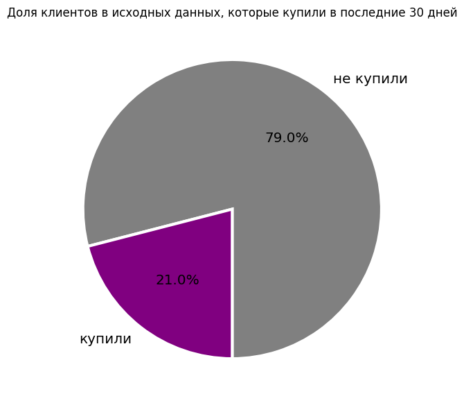

```python
sizes = df_sort_history['target'].value_counts(sort = True)
colors = ["grey","purple"]
fig, axes = plt.subplots(1, figsize = (7,7))
labels= ['не купили', 'купили']

plt.pie(sizes,
        colors=colors,
        autopct='%1.1f%%',
        startangle=270,
        wedgeprops={'linewidth': 3.0, 'edgecolor': 'white'},
        textprops={'size': 'x-large'},
        labels = labels,
        )

plt.title('Доля клиентов в исходных данных, которые купили в последние 30 дней')
plt.show()
```

Видим, что при подходе решения с временным рядом - баланс классов сильно отличается в лучшую сторону - целевой признак составляет 21%. Теперь посмотрим на корреляцию признаков.

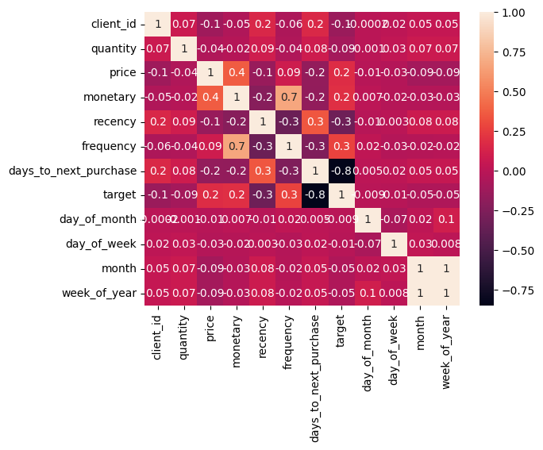

```python
sns.heatmap(df_sort_history.corr(), annot = True, fmt='.1g')
```

Видим зависимость признаков target и next_day_purchase - что логично, мы же выбирали по этому столбцу целевой признак. И полную зависимость признаков month и week_of_year. Это значит, что можно оставить было всего один из них.

Разделим данные, так как это временной ряд - не будем их перемешивать.

```python
train, test = train_test_split(df_sort_history, shuffle=False, test_size=0.2)
```

```python
target_train = train['target']
features_train = train.drop(['client_id','days_to_next_purchase','target'], axis =1)

target_test = test['target']
features_test = test.drop(['client_id','days_to_next_purchase','target'], axis =1)
```

```python
print(features_train.shape)
print(features_test.shape)
```

```
(49189, 9)
(12298, 9)
```

```python
print("Проверим индексы разбиений для features_train")
print(features_train.index.min())
print(features_train.index.max())
print("Проверим индексы разбиений для features_test")
print(features_test.index.min())
print(features_test.index.max())
```

```
Проверим индексы разбиений для features_train
2022-10-26
2023-07-03
Проверим индексы разбиений для features_test
2023-07-03
2023-09-26
```

```python
print("Проверим индексы разбиений для target_train")
print(target_train.index.min())
print(target_train.index.max())
print("Проверим индексы разбиений для target_test")
print(target_test.index.min())
print(target_test.index.max())
```

```
Проверим индексы разбиений для target_train
2022-10-26
2023-07-03
Проверим индексы разбиений для target_test
2023-07-03
2023-09-26
```

```python
features_train
```

|  | quantity | price | monetary | recency | frequency | day_of_month | day_of_week | month | week_of_year |
| --- | --- | --- | --- | --- | --- | --- | --- | --- | --- |
| 2022-10-26 | 1 | 2499.0 | 2499.0 | 999 | 1 | 26 | 2 | 10 | 43 |
| 2022-10-26 | 3 | 2213.0 | 2213.0 | 999 | 1 | 26 | 2 | 10 | 43 |
| 2022-10-26 | 2 | 7998.0 | 7998.0 | 999 | 1 | 26 | 2 | 10 | 43 |
| 2022-10-26 | 2 | 17998.0 | 17998.0 | 999 | 1 | 26 | 2 | 10 | 43 |
| 2022-10-26 | 1 | 2100.0 | 2100.0 | 999 | 1 | 26 | 2 | 10 | 43 |
| ... | ... | ... | ... | ... | ... | ... | ... | ... | ... |
| 2023-07-03 | 2 | 1198.0 | 1198.0 | 999 | 1 | 3 | 0 | 7 | 27 |
| 2023-07-03 | 10 | 1927.0 | 1927.0 | 999 | 1 | 3 | 0 | 7 | 27 |
| 2023-07-03 | 2 | 4998.0 | 4998.0 | 999 | 1 | 3 | 0 | 7 | 27 |
| 2023-07-03 | 4 | 19996.0 | 19996.0 | 999 | 1 | 3 | 0 | 7 | 27 |
| 2023-07-03 | 11 | 1689.0 | 1689.0 | 999 | 1 | 3 | 0 | 7 | 27 |

49189 rows × 9 columns

Потроим модели RandomForestClassifier, LogisticRegression и CatBoostClassifier

```python
rfc = RandomForestClassifier(random_state=RS)      # Определение объекта классификатора RandomForestClassifier
lr = LogisticRegression(random_state=RS,
                        solver = 'liblinear')      # Определение объекта классификатора LogisticRegression
cb = CatBoostClassifier(random_state=RS)           # Определение объекта классификатора CatBoostClassifier
dm = DummyClassifier(strategy="most_frequent", random_state=RS)        # Определение объекта классификатора DummyClassifier


gscv_rfc = GridSearchCV(estimator=rfc, param_grid=rfc_params, scoring='roc_auc', cv=3)  # Определение объекта кросс-валидации для RandomForestClassifier
gscv_lr = GridSearchCV(estimator=lr, param_grid=lr_params, scoring='roc_auc', cv=3)     # Определение объекта кросс-валидации для LogisticRegression
gscv_cb = GridSearchCV(estimator=cb, param_grid=cb_params, scoring='roc_auc',  cv=3)     # Определение объекта кросс-валидации для CatBoost

rfc_model = gscv_rfc.fit(features_train, target_train)  # Обучение модели RandomForestClassifier на кросс-валидации
lr_model = gscv_lr.fit(features_train, target_train)    # Обучение модели LogisticRegression на кросс-валидации
cb_model = gscv_cb.fit(features_train, target_train)    # Обучение модели CatBoost на кросс-валидации на сырых данных
dm_model = dm.fit(features_train, target_train)
```

```python
# Получение лучших параметров для классификаторов полученных на кросс-валидации
print('Лучшие параметры:')
print(f'RandomForestClassifier %s \nLogisticRegression %s \nCatBoostClassifier %s' %(
                                                                gscv_rfc.best_params_,
                                                                gscv_lr.best_params_,
                                                                gscv_cb.best_params_))
```

```
Лучшие параметры:
RandomForestClassifier {'class_weight': 'balanced', 'max_depth': 10, 'min_samples_leaf': 6, 'n_estimators': 90}
LogisticRegression {'C': 0.9000000000000001, 'class_weight': 'balanced'}
CatBoostClassifier {'iterations': 300, 'l2_leaf_reg': 9, 'learning_rate': 0.1, 'verbose': False}
```

Сделаем предсказания

```python
rfc_predict = rfc_model.predict(features_test)
lr_predict = lr_model.predict(features_test)
cb_predict = cb_model.predict(features_test)
dm_predict = dm_model.predict(features_test)
```

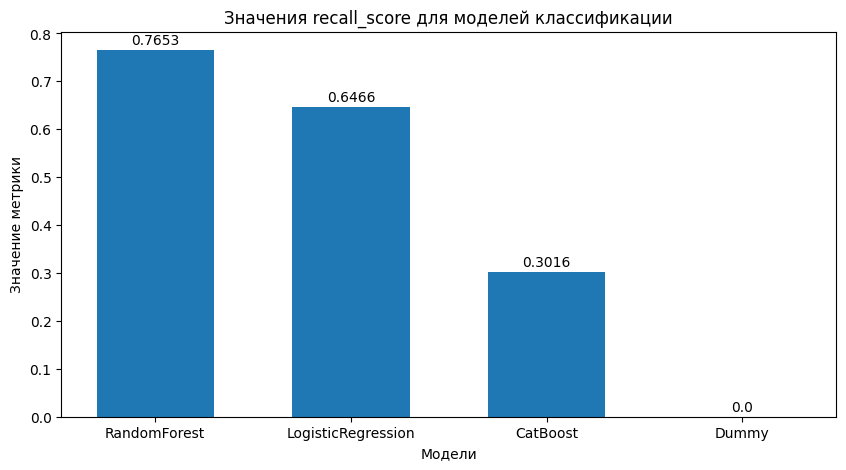

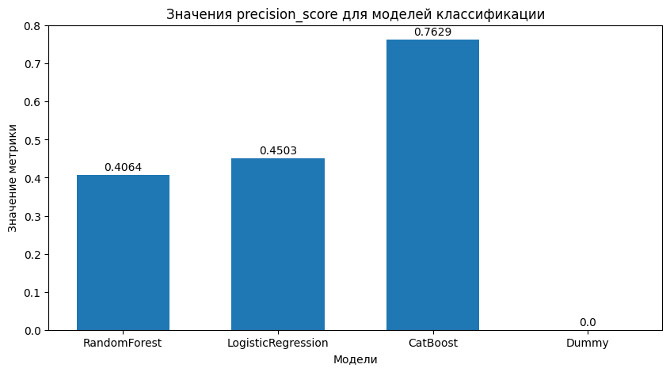

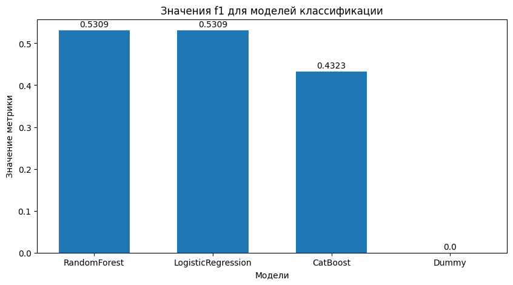

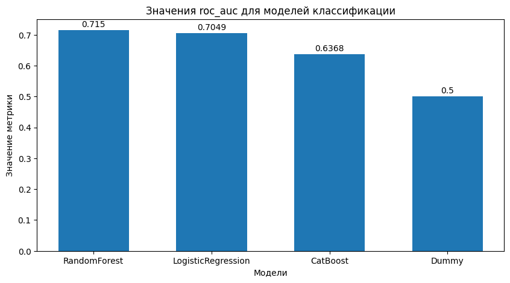

```python
# Получение значений полноты моделей классификаторов
metrics_scores = [recall_score, precision_score, f1_score, roc_auc_score]
predicts = [rfc_predict, lr_predict, cb_predict, dm_predict]
models_names = ['RandomForest', 'LogisticRegression', 'CatBoost', 'Dummy']
scores_names = ['recall_score', 'precision_score', 'f1', 'roc_auc']
values_list = []
values_list_tab = []

for i, score in enumerate(metrics_scores):
    for predict in predicts:
        values_list.append(round(score(target_test, predict),4))

    x = np.arange(len(models_names))  # Список координат столбцов по x

    fig, ax = plt.subplots(figsize=(10,5))  # Определение фигуры и осей
    rects = ax.bar(x, values_list, 0.6)  # Определение колонок для данных

    # Указание подписей для осей, таблицы, легенды
    ax.set_ylabel('Значение метрики')
    ax.set_xlabel('Модели')
    ax.set_title(f'Значения {scores_names[i]} для моделей классификации')
    ax.set_xticks(x)
    ax.set_xticklabels(models_names)

    # Определение функции для отображения столбцов с аннотациями
    def autolabel(rects):
        for rect in rects:
            height = rect.get_height()
            # Задание параметров для аннотаций
            ax.annotate('{}'.format(height),
                        xy=(rect.get_x() + rect.get_width() / 2, height), # Получение точек координат для текста
                        xytext=(0, 2),    # Высота текста над столбцами
                        # Расположение текста относительно столбцов
                        textcoords="offset points",
                        ha='center', va='bottom')

    autolabel(rects)  # Выполнение функции
    values_list_tab.append(values_list)
    values_list = []

plt.show()
```

```python
values_list_df = pd.DataFrame(values_list_tab)
```

```python
values_list_df.columns = models_names
values_list_df.index = scores_names
values_list_df
```

|  | RandomForest | LogisticRegression | CatBoost | Dummy |
| --- | --- | --- | --- | --- |
| recall_score | 0.7653 | 0.6466 | 0.3016 | 0.0 |
| precision_score | 0.4064 | 0.4503 | 0.7629 | 0.0 |
| f1 | 0.5309 | 0.5309 | 0.4323 | 0.0 |
| roc_auc | 0.7150 | 0.7049 | 0.6368 | 0.5 |

Выберем модель, которая балансирует между точностью и полнотой - LogisticRegression. Ее параметры LogisticRegression {'C': 0.9000000000000001, 'class_weight': 'balanced'}